# Introduction à la bioinformatique en Oncologie

## Autre exemple d’application: détection de gènes de fusion

Ce chromosome est une aberration qui n’est pas héritée et qui n’est pas transmissible à sa descendance.

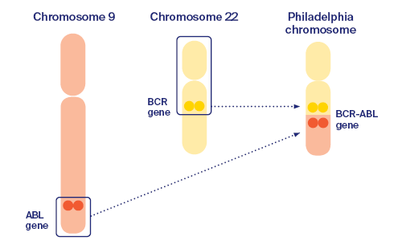

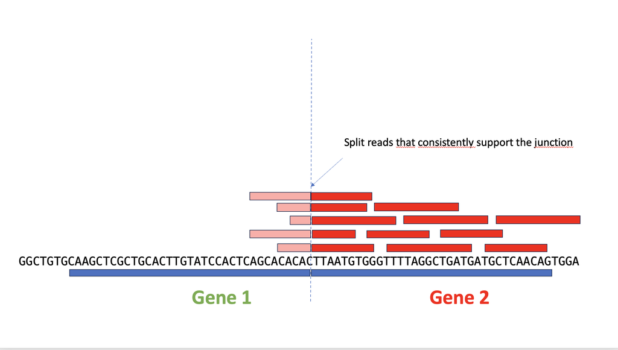

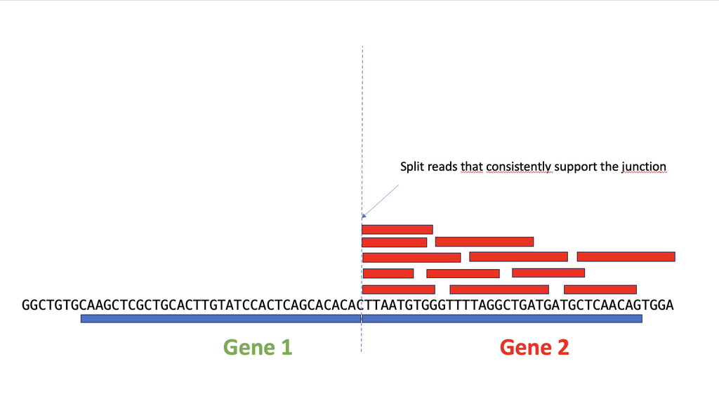

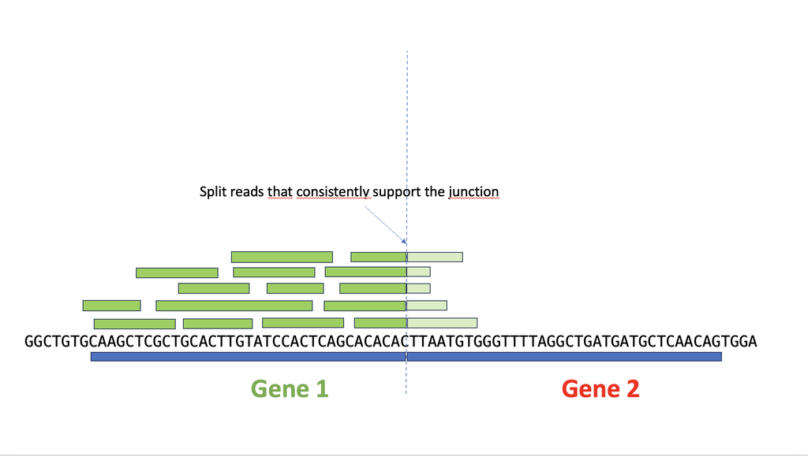

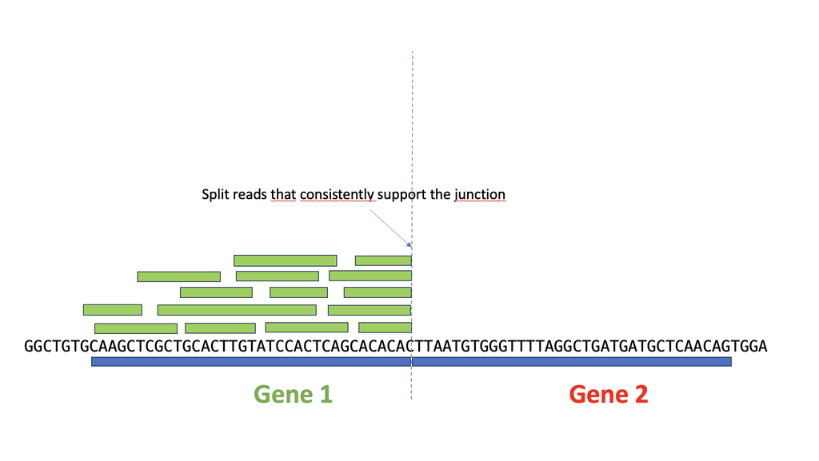

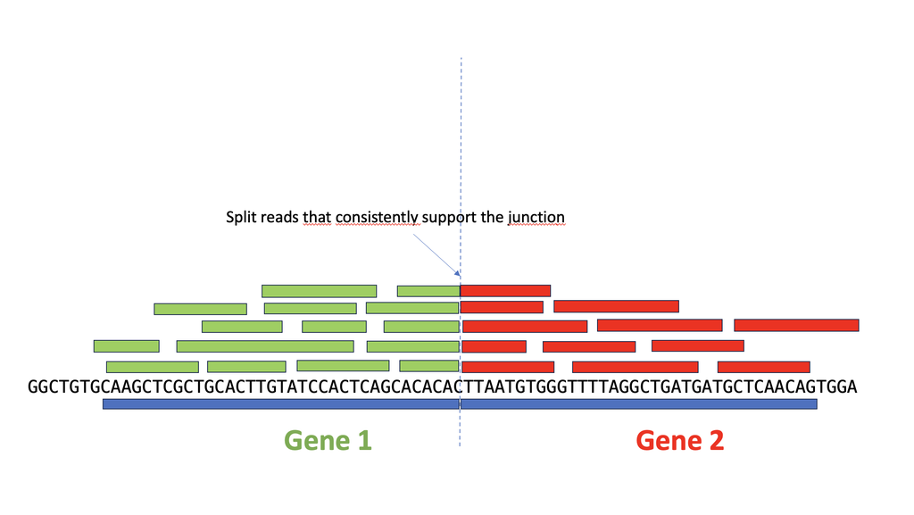

## Analyse fonctionnelle

Après avoir identifié une liste de gènes d’interêt (par exemple après une analyse différentielle), nous cherchons à obtenir la **fonction biologique** des gènes présents dans cette liste.

Deux manières de procéder:

- Parcourir la liste “à la main” et faire une recherche dans la littérature pour chaque gène… long et fastidieux!
- Utiliser les annotations des gènes pour décrouvrir les fonctions moléculaires ou pathways représentés par ces gènes: -> Faire une **Analyse d’enrichissement fonctionnelle**. On peut ensuite retourner vers la littérature.

## Analyse fonctionnelle par enrichissement GO

Elles sont basées sur deux composantes:

- Elles utilisent une **Ontologie** (vocabulaire **contrôlé et stable** mis en place par le **Gene Ontology Consortium** ou autre (**Kyoto Encyclopedia of Genes and Genomes, KEGG**)).
- D’où l’utilisation fréquente du raccourci (Enrichissement **GO**)
- Elles sont basées sur un **Enrichissement Fonctionnel** associé à une **validation statistique par Test Hypergéométrique**.

## Qu’est ce qu’une ontologie ?

Une ontologie est l’**ensemble structuré des termes et concepts représentant le sens d’un champ d’informations**, que ce soit par les métadonnées d’un espace de noms, ou les éléments d’un domaine de connaissances.

Application au génome: **Gene Ontology** (*Gene Ontology Consortium*http://www.amigo.org). 3 ontologies ont été définies.

- **Biological Process**
- **Cellular Component**
- **Molecular Function**

## Exemple d’annotation

**Gène TP53**

[figure not shown]

Annotations par un **vocabulaire contrôlé**.

## Analyse fonctionnelle par enrichissement: principe (1)

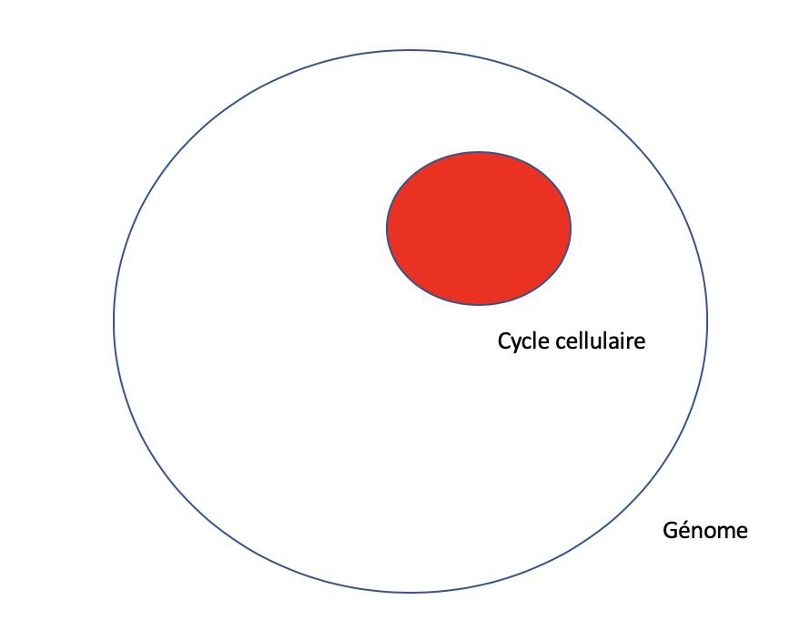

## Analyse fonctionnelle par enrichissement: principe (2)

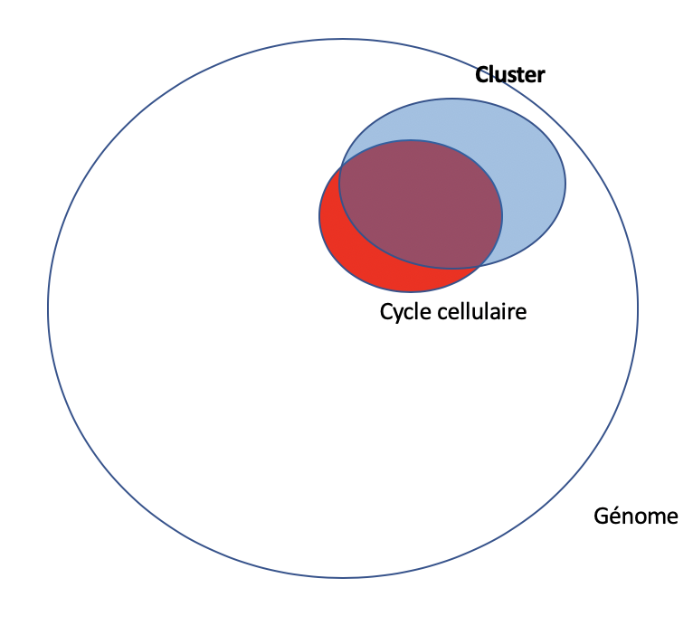

## Test d’enrichissement GO

Une catégorie *C* de gènes regroupe *n* gènes sur le total de *N* présents dans le génome. **La fréquence de départ de cette catégorie est** \(F = n/N\).

Nous avons ensuite obtenu un cluster de \(k\) gènes significativement exprimés ou sous-exprimés, dont *p* appartiennent à la catégorie *C*.

Le test d’enrichissement doit répondre à la question: L’enrichissement est-il **statistiquement significatif** par rapport à un tirage au hasard? Une pratique courante est de le faire par l’application d’un **Test hypergéométrique**.

## Exemple de résultat

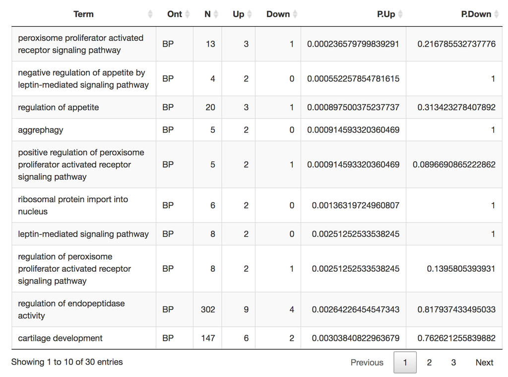

## Banques de données publiques NCBI

Il s’agit de Dépôts de données liées à des publications répondant à des standards minimum de conservation et de reproductibilité de l’information, et contenant des données brutes de puces à ADN et de NGS.

L’information stockée permet la reproductibilité de l’expérience Leur usage est exigé pour publication (Numéro d’accession).

- **NCBI Gene Expression Omnibus** http://www.ncbi.nlm.nih.gov/geo/
- **EBI ArrayExpress** http://www.ebi.ac.uk/arrayexpress/

Dépôts spécialisés:

- The Cancer Cell Line Encyclopedia (CCLE) http://www.broadinstitute.org/ccle
- The Cancer Genome Atlas (TCGA) http://cancergenome.nih.gov/
- Immunological Genome Project (ImmGen) https://www.immgen.org/

## Bases d’annotations utiles

- Téléchargement de génomes de références (souris, humain et autres): UCSC http://hgdownload.cse.ucsc.edu/goldenPath/hg19/bigZips/hg19.2bit
- Téléchargement d’annotations sous format GFF (pour IGV): GENCODE https://www.gencodegenes.org/human/

## Autres services NCBI

PubMed:

http://www.ncbi.nlm.nih.gov/pubmed

- Recherches par *auteur*, *années*, *titre*, *contenu du résumé*
- Recherche par *publications en lien*
- Possibilité d’ouvrir un compte utilisateur NCBI (*Recherches favorites*, *Recherches automatisées*)
- Un grand nombre de publications sont accessibles librement (*PubMed Central*)

## Petit Quizz

- **En analyse NGS, la bioinformatique et l’infrastructure bioinformatique ne sont que peu ou pas importantes face au séquençage lui-même**: (*Vrai/Faux*)
- **Remettre dans l’ordre les phases d’analyse de variants suivantes**:
  - Alignement
  - Détection des mutations et Production des VCFs
  - Visualisation
  - Annotation des variants
  - Contrôle Qualité
- **Faire correspondre les logiciels suivants à ces différentes étapes**:
  - BWA
  - IGV
  - Annovar
  - Varscan
  - FastQC

## Merci pour votre attention !

- Contact ghislain.bidaut@inserm.fr
- Site web https://www.crcm-marseille.fr/equipes/plateformestechnologiques/plateforme-de-bioinformatique-integrative-cibi/

Ce(tte) œuvre est mise à disposition selon les termes de la [Licence Creative Commons Attribution - Pas d'Utilisation Commerciale - Pas de Modification 4.0 International](http://creativecommons.org/licenses/by-nc-nd/4.0/).